# Project: TMDB Movies Data

- Introduction
- Data Wrangling
- Exploratory Data Analysis
- Conclusions

## Introduction

> In this project, we are going to look into a data set which contains about 10,000 movies gathered from the Movie Database (TMDb), it includes 21 columns such as cast, director, budget, revenue and ratings etc.

```python
import pandas as pd
import numpy as np
import matplotlib.pyplot as plt
import seaborn as sns
sns.set_style('darkgrid')
from numpy import nan
%matplotlib inline
```

## Data Wrangling

### General Properties

```python
df = pd.read_csv('tmdb-movies.csv')

df.head(3)
```

|  | id | imdb_id | popularity | budget | revenue | original_title | cast | homepage | director | tagline | ... | overview | runtime | genres | production_companies | release_date | vote_count | vote_average | release_year | budget_adj | revenue_adj |
| --- | --- | --- | --- | --- | --- | --- | --- | --- | --- | --- | --- | --- | --- | --- | --- | --- | --- | --- | --- | --- | --- |
| 0 | 135397 | tt0369610 | 32.985763 | 150000000 | 1513528810 | Jurassic World | Chris Pratt\|Bryce Dallas Howard\|Irrfan Khan\|Vi... | http://www.jurassicworld.com/ | Colin Trevorrow | The park is open. | ... | Twenty-two years after the events of Jurassic ... | 124 | Action\|Adventure\|Science Fiction\|Thriller | Universal Studios\|Amblin Entertainment\|Legenda... | 6/9/15 | 5562 | 6.5 | 2015 | 1.379999e+08 | 1.392446e+09 |
| 1 | 76341 | tt1392190 | 28.419936 | 150000000 | 378436354 | Mad Max: Fury Road | Tom Hardy\|Charlize Theron\|Hugh Keays-Byrne\|Nic... | http://www.madmaxmovie.com/ | George Miller | What a Lovely Day. | ... | An apocalyptic story set in the furthest reach... | 120 | Action\|Adventure\|Science Fiction\|Thriller | Village Roadshow Pictures\|Kennedy Miller Produ... | 5/13/15 | 6185 | 7.1 | 2015 | 1.379999e+08 | 3.481613e+08 |
| 2 | 262500 | tt2908446 | 13.112507 | 110000000 | 295238201 | Insurgent | Shailene Woodley\|Theo James\|Kate Winslet\|Ansel... | http://www.thedivergentseries.movie/#insurgent | Robert Schwentke | One Choice Can Destroy You | ... | Beatrice Prior must confront her inner demons ... | 119 | Adventure\|Science Fiction\|Thriller | Summit Entertainment\|Mandeville Films\|Red Wago... | 3/18/15 | 2480 | 6.3 | 2015 | 1.012000e+08 | 2.716190e+08 |

3 rows × 21 columns

In the steps below we shall try to get a general overview of the data set by looking at the shape, information.

```python
print('Shape')
print(df.shape)
print('\nData Information ')
df.info()
```

```
Shape
(10866, 21)

Data Information
<class 'pandas.core.frame.DataFrame'>
RangeIndex: 10866 entries, 0 to 10865
Data columns (total 21 columns):
 #   Column                Non-Null Count  Dtype
---  ------                --------------  -----
 0   id                    10866 non-null  int64
 1   imdb_id               10856 non-null  object
 2   popularity            10866 non-null  float64
 3   budget                10866 non-null  int64
 4   revenue               10866 non-null  int64
 5   original_title        10866 non-null  object
 6   cast                  10790 non-null  object
 7   homepage              2936 non-null   object
 8   director              10822 non-null  object
 9   tagline               8042 non-null   object
 10  keywords              9373 non-null   object
 11  overview              10862 non-null  object
 12  runtime               10866 non-null  int64
 13  genres                10843 non-null  object
 14  production_companies  9836 non-null   object
 15  release_date          10866 non-null  object
 16  vote_count            10866 non-null  int64
 17  vote_average          10866 non-null  float64
 18  release_year          10866 non-null  int64
 19  budget_adj            10866 non-null  float64
 20  revenue_adj           10866 non-null  float64
dtypes: float64(4), int64(6), object(11)
memory usage: 1.7+ MB
```

> From the above it can be seen that the data contains 10866 entries and 21 columns. Also, it reveals that there are some missing values.

> We shall go further to get a descriptive statistics of the data.

```python
df.describe()
```

|  | id | popularity | budget | revenue | runtime | vote_count | vote_average | release_year | budget_adj | revenue_adj |
| --- | --- | --- | --- | --- | --- | --- | --- | --- | --- | --- |
| count | 10866.000000 | 10866.000000 | 1.086600e+04 | 1.086600e+04 | 10866.000000 | 10866.000000 | 10866.000000 | 10866.000000 | 1.086600e+04 | 1.086600e+04 |
| mean | 66064.177434 | 0.646441 | 1.462570e+07 | 3.982332e+07 | 102.070863 | 217.389748 | 5.974922 | 2001.322658 | 1.755104e+07 | 5.136436e+07 |
| std | 92130.136561 | 1.000185 | 3.091321e+07 | 1.170035e+08 | 31.381405 | 575.619058 | 0.935142 | 12.812941 | 3.430616e+07 | 1.446325e+08 |
| min | 5.000000 | 0.000065 | 0.000000e+00 | 0.000000e+00 | 0.000000 | 10.000000 | 1.500000 | 1960.000000 | 0.000000e+00 | 0.000000e+00 |
| 25% | 10596.250000 | 0.207583 | 0.000000e+00 | 0.000000e+00 | 90.000000 | 17.000000 | 5.400000 | 1995.000000 | 0.000000e+00 | 0.000000e+00 |
| 50% | 20669.000000 | 0.383856 | 0.000000e+00 | 0.000000e+00 | 99.000000 | 38.000000 | 6.000000 | 2006.000000 | 0.000000e+00 | 0.000000e+00 |
| 75% | 75610.000000 | 0.713817 | 1.500000e+07 | 2.400000e+07 | 111.000000 | 145.750000 | 6.600000 | 2011.000000 | 2.085325e+07 | 3.369710e+07 |
| max | 417859.000000 | 32.985763 | 4.250000e+08 | 2.781506e+09 | 900.000000 | 9767.000000 | 9.200000 | 2015.000000 | 4.250000e+08 | 2.827124e+09 |

> From the description of the dataset it can be seen that there are some unrealistic values such as the **budget** and **revenue** having a minimum values of zero (0).

### Dropping Extraneous Columns

Below we shall columns that not relevant to the questions we wish to address in this project.

```python
df.drop(columns=['overview','homepage','tagline','original_title','release_date','keywords'],inplace= True)
# let's confirm these cloumns have been dropped
df.columns
```

```
Index(['id', 'imdb_id', 'popularity', 'budget', 'revenue', 'cast', 'director',
       'runtime', 'genres', 'production_companies', 'vote_count',
       'vote_average', 'release_year', 'budget_adj', 'revenue_adj'],
      dtype='object')
```

## Data Cleaning

> Here, we shall check the total number of missing vlaues in each cloumn of the dataset.

### Drop Rows with Missing Values

```python
df.isnull().sum()
```

```
id                         0
imdb_id                   10
popularity                 0
budget                     0
revenue                    0
cast                      76
director                  44
runtime                    0
genres                    23
production_companies    1030
vote_count                 0
vote_average               0
release_year               0
budget_adj                 0
revenue_adj                0
dtype: int64
```

```python
df.dropna(inplace=True)
df.isnull().sum().any()
```

```
False
```

```python
print(df.shape)
```

```
(9771, 15)
```

## Dropping Rows with Duplicated Values

```python
df.duplicated().sum()
```

```
1
```

```python
df.drop_duplicates(inplace= True)
df.duplicated().sum().any()
```

```
False
```

# Dealing with values outside realistic range

To address unrealistic values which was detected from the descriptive statistics, we shall replace every row that has a zero value with 'nan'. Then find out the total numbers of such entries.

```python
# replace zeros with 'nan'

df = df.replace(0, nan)
print(df.isnull().sum())
```

```
id                         0
imdb_id                    0
popularity                 0
budget                  4749
revenue                 5020
cast                       0
director                   0
runtime                   13
genres                     0
production_companies       0
vote_count                 0
vote_average               0
release_year               0
budget_adj              4749
revenue_adj             5020
dtype: int64
```

For the runtime we are going to assume that the values are missing at completely as such that, the missing values are distributed similarly to values that are present (MCAR). Thus, we shall fill it with the mean value

```python
df['runtime'].fillna(df['runtime'].mean(), inplace=True)
```

```python
df.dropna(inplace=True)
df.isnull().sum().any()
```

```
False
```

## Inspecting and fixing data types

```python
df.dtypes
```

```
id                        int64
imdb_id                  object
popularity              float64
budget                  float64
revenue                 float64
cast                     object
director                 object
runtime                 float64
genres                   object
production_companies     object
vote_count                int64
vote_average            float64
release_year              int64
budget_adj              float64
revenue_adj             float64
dtype: object
```

```python
df['runtime'] = df['runtime'].astype(int)
```

## Exploratory Data Analysis

Now that the data has been cleaned and trimmed. We go ahead now now check the shape of the data we now have, compute descriptive statistics and also check the distribution.

```python
print('Shape:' , df.shape)
df.describe()
```

```
Shape: (3805, 15)
```

|  | id | popularity | budget | revenue | runtime | vote_count | vote_average | release_year | budget_adj | revenue_adj |
| --- | --- | --- | --- | --- | --- | --- | --- | --- | --- | --- |
| count | 3805.000000 | 3805.000000 | 3.805000e+03 | 3.805000e+03 | 3805.000000 | 3805.000000 | 3805.000000 | 3805.000000 | 3.805000e+03 | 3.805000e+03 |
| mean | 40040.372668 | 1.203784 | 3.760800e+07 | 1.089734e+08 | 109.351117 | 534.159001 | 6.170565 | 2001.229172 | 4.471977e+07 | 1.387159e+08 |
| std | 67585.708616 | 1.480569 | 4.232179e+07 | 1.772976e+08 | 19.845678 | 883.757588 | 0.792437 | 11.329616 | 4.488697e+07 | 2.169973e+08 |
| min | 5.000000 | 0.010335 | 1.000000e+00 | 2.000000e+00 | 15.000000 | 10.000000 | 2.200000 | 1960.000000 | 9.693980e-01 | 2.370705e+00 |
| 25% | 5925.000000 | 0.470651 | 1.000000e+07 | 1.433379e+07 | 96.000000 | 74.000000 | 5.700000 | 1995.000000 | 1.354637e+07 | 1.925371e+07 |
| 50% | 11253.000000 | 0.810805 | 2.500000e+07 | 4.621664e+07 | 106.000000 | 209.000000 | 6.200000 | 2004.000000 | 3.038360e+07 | 6.284688e+07 |
| 75% | 38579.000000 | 1.387163 | 5.000000e+07 | 1.260695e+08 | 119.000000 | 584.000000 | 6.700000 | 2010.000000 | 6.084153e+07 | 1.658054e+08 |
| max | 417859.000000 | 32.985763 | 4.250000e+08 | 2.781506e+09 | 338.000000 | 9767.000000 | 8.400000 | 2015.000000 | 4.250000e+08 | 2.827124e+09 |

```python
df.nunique()
```

```
id                      3805
imdb_id                 3805
popularity              3803
budget                   399
revenue                 3710
cast                    3784
director                1683
runtime                  136
genres                  1043
production_companies    3005
vote_count              1274
vote_average              53
release_year              56
budget_adj              2076
revenue_adj             3800
dtype: int64
```

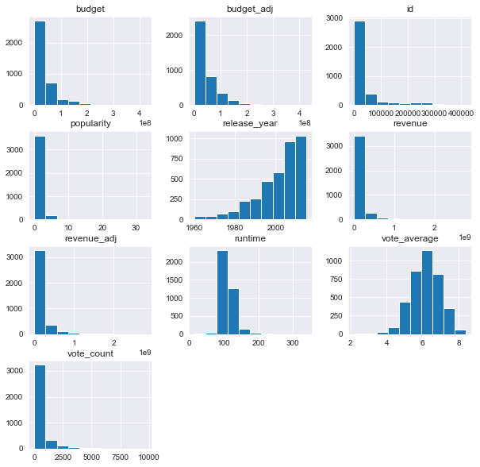

```python
df.hist(figsize =(10,10));
```

### What type (genre) of movies are produced over the years?

To achieve this, we loop over the years to count the number of each unique genre and appending it to a list and then transpose it in other to add it to the dataframe.

```python
DF = pd.read_csv('genres.csv')
```

```python
#['Comedy', 'Action', 'Adventure', 'Western', 'Science Fiction', 'Drama', 'Family', 'Crime', 'Romance', 'War', 'Thriller','Fantasy', 'History','Mystery', 'Animation', 'Horror', 'Music', 'Documentary', 'TVMovie','Foreign']



numbers=[]
year = 1960
while year < 2016:
    d_year = df['release_year'] == year
    iscomedy = df['genres'].str.contains('Foreign')
    Y = df[iscomedy & d_year]
    G = Y['genres'].count()
    numbers.append(G)
    year = year + 1


J = np.transpose(numbers)
DF['Foreign'] = J
DF.head()
```

|  | year | Foreign |
| --- | --- | --- |
| 0 | 1960 | 0 |
| 1 | 1961 | 0 |
| 2 | 1962 | 0 |
| 3 | 1963 | 0 |
| 4 | 1964 | 0 |

```python
DF.to_csv('genres_year.csv',index=False)
```

```python
DF1 = pd.read_csv('genres_years.csv',index_col='year')
DF1.head()
```

| year | Comedy | Action | Adventure | Western | Science Fiction | Drama | Family | Crime | Romance | War | Thriller | Fantasy | History | Mystery | Animation | Horror | Music | Documentary | TVMovie | Foreign |
| --- | --- | --- | --- | --- | --- | --- | --- | --- | --- | --- | --- | --- | --- | --- | --- | --- | --- | --- | --- | --- |
| 1960 | 2 | 2 | 1 | 1 | 0 | 3 | 0 | 0 | 2 | 0 | 1 | 0 | 1 | 0 | 0 | 1 | 0 | 0 | 0 | 0 |
| 1961 | 4 | 2 | 2 | 1 | 0 | 6 | 2 | 1 | 1 | 1 | 0 | 0 | 1 | 0 | 1 | 1 | 1 | 0 | 0 | 0 |
| 1962 | 0 | 2 | 3 | 2 | 0 | 5 | 0 | 1 | 0 | 1 | 1 | 0 | 1 | 0 | 0 | 0 | 0 | 0 | 0 | 0 |
| 1963 | 1 | 2 | 2 | 0 | 0 | 3 | 0 | 0 | 2 | 1 | 3 | 0 | 3 | 1 | 0 | 1 | 0 | 0 | 0 | 0 |
| 1964 | 3 | 1 | 1 | 0 | 0 | 4 | 2 | 1 | 2 | 1 | 2 | 1 | 0 | 1 | 0 | 0 | 3 | 0 | 0 | 0 |

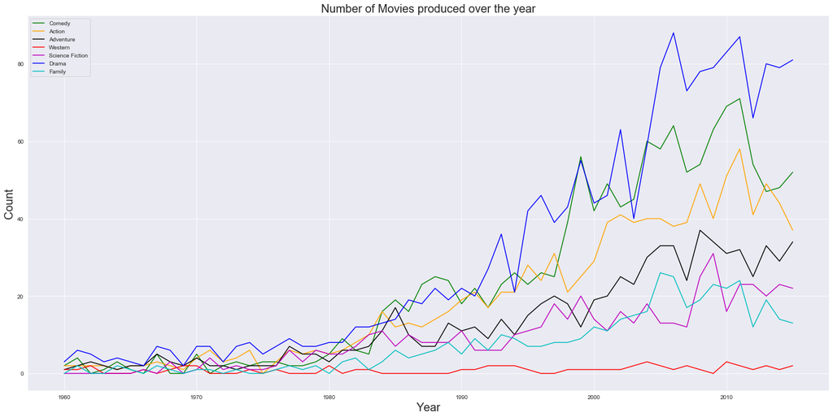

```python
plt.figure(figsize =(25,12))
plt.plot(DF1['Comedy'],color='g',label='Comedy',fillstyle='none');
plt.plot(DF1['Action'],color='orange',label='Action',fillstyle='none');
plt.plot(DF1['Adventure'],color='k',label='Adventure',fillstyle='none');
plt.plot(DF1['Western'],color='r',label='Western',fillstyle='none');
plt.plot(DF1['Science Fiction'],color='m',label='Science Fiction',fillstyle='none');
plt.plot(DF1['Drama'],color='b',label='Drama',fillstyle='none');
plt.plot(DF1['Family'],color='c',label='Family',fillstyle='none');

plt.rc('xtick', labelsize=20)
plt.rc('ytick', labelsize=20)

plt.legend();
plt.rc('legend',fontsize=20)
plt.xlabel('Year',fontsize=20)
plt.ylabel('Count',fontsize=20)
plt.title('Number of Movies produced over the year',fontsize=20);
```

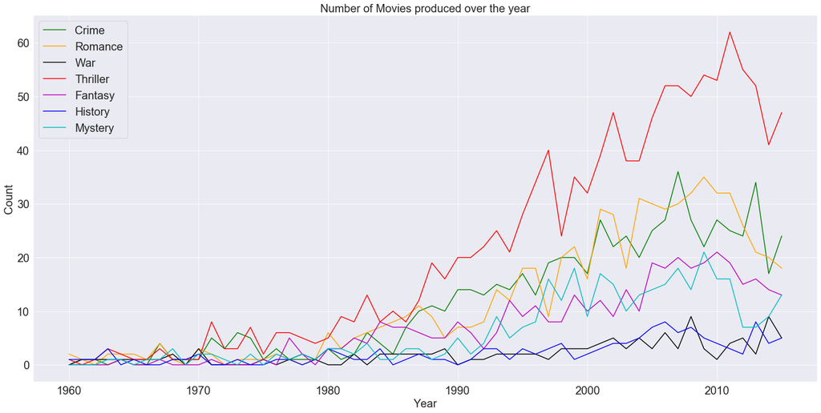

```python
plt.figure(figsize =(25,12))
plt.plot(DF1['Crime'],color='g',label='Crime',fillstyle='none');
plt.plot(DF1['Romance'],color='orange',label='Romance',fillstyle='none');
plt.plot(DF1['War'],color='k',label='War',fillstyle='none');
plt.plot(DF1['Thriller'],color='r',label='Thriller',fillstyle='none');
plt.plot(DF1['Fantasy'],color='m',label='Fantasy',fillstyle='none');
plt.plot(DF1['History'],color='b',label='History',fillstyle='none');
plt.plot(DF1['Mystery'],color='c',label='Mystery',fillstyle='none');

plt.rc('xtick', labelsize=20)
plt.rc('ytick', labelsize=20)

plt.legend();
plt.rc('legend',fontsize=20)
plt.xlabel('Year',fontsize=20)
plt.ylabel('Count',fontsize=20)
plt.title('Number of Movies produced over the year',fontsize=20);
```

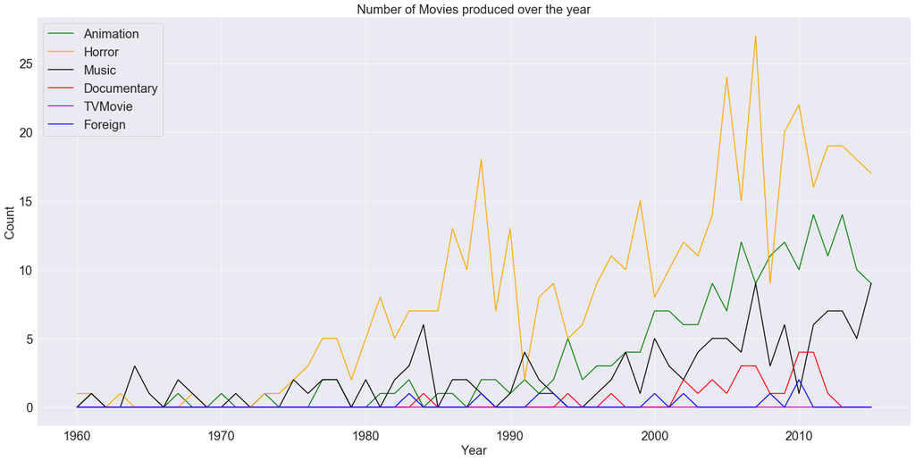

```python
plt.figure(figsize =(25,12))
plt.plot(DF1['Animation'],color='g',label='Animation',fillstyle='none');
plt.plot(DF1['Horror'],color='orange',label='Horror',fillstyle='none');
plt.plot(DF1['Music'],color='k',label='Music',fillstyle='none');
plt.plot(DF1['Documentary'],color='r',label='Documentary',fillstyle='none');
plt.plot(DF1['TVMovie'],color='m',label='TVMovie',fillstyle='none');
plt.plot(DF1['Foreign'],color='b',label='Foreign',fillstyle='none');

plt.rc('xtick', labelsize=20)
plt.rc('ytick', labelsize=20)

plt.legend();
plt.rc('legend',fontsize=20)
plt.xlabel('Year',fontsize=20)
plt.ylabel('Count',fontsize=20)
plt.title('Number of Movies produced over the year',fontsize=20);
```

> The figures above shows that starting from the year 2000 the movies been produced are **Drama, Comedy, Thriller and Action**

### Does movies with less runtime recieve higher vote?

> Here we try to split the runtime into high and low using the median, then we find the average vote for both.

```python
R_mean =df['runtime'].median()
R_mean
```

```
106.0
```

```python
low_runtime =df[df['runtime']< R_mean]
high_runtime =df[df['runtime']>= R_mean]
Samples = df.shape[0]
Samples == low_runtime['vote_average'].count() + high_runtime['vote_average'].count() # should be True
```

```
True
```

```python
mean_low_vote = low_runtime['vote_average'].mean()
mean_high_vote =high_runtime['vote_average'].mean()
print(mean_low_vote, mean_high_vote)
```

```
5.918581259925889 6.418997912317343
```

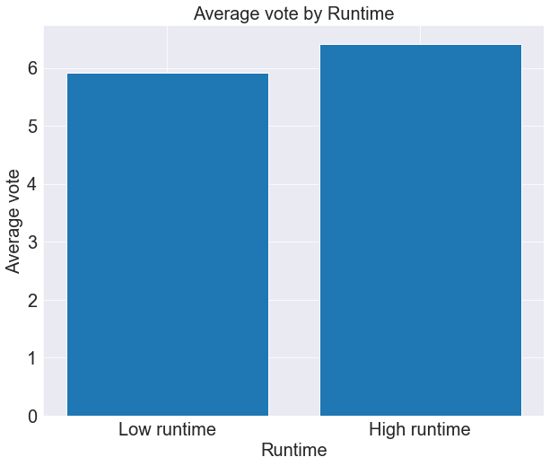

```python
plt.figure(figsize =(10,8))
locations = [1, 2]
heights = [mean_low_vote, mean_high_vote]
labels = ['Low runtime', 'High runtime']
plt.bar(locations, heights, tick_label=labels)
plt.title('Average vote by Runtime',fontsize=20)
plt.xlabel('Runtime',fontsize=20)
plt.ylabel('Average vote',fontsize=20);
```

From the diagram, it is seen that the movies with lower runtime actually recieve lesser vote compared to those with a higer runtime.

### What kind of properties are associated with movies that have higher revenues?

> To get the movies with higher revenues, we selected those whose revenue is greater than the average revenue for the dataset. Then, we obtain a descriptive statistics for it.

```python
Rev =df['revenue'].mean()
high_revenue =df[df['revenue']>= Rev]
high_revenue.describe()
```

|  | id | popularity | budget | revenue | runtime | vote_count | vote_average | release_year | budget_adj | revenue_adj |
| --- | --- | --- | --- | --- | --- | --- | --- | --- | --- | --- |
| count | 1095.000000 | 1095.000000 | 1.095000e+03 | 1.095000e+03 | 1095.000000 | 1095.000000 | 1095.000000 | 1095.000000 | 1.095000e+03 | 1.095000e+03 |
| mean | 35945.962557 | 2.201642 | 7.449737e+07 | 2.954684e+08 | 115.606393 | 1250.768950 | 6.392877 | 2003.270320 | 8.349348e+07 | 3.592161e+08 |
| std | 61538.961579 | 2.221929 | 5.465937e+07 | 2.412660e+08 | 21.166688 | 1284.627864 | 0.709806 | 9.470535 | 5.440947e+07 | 2.938077e+08 |
| min | 11.000000 | 0.131526 | 1.130000e+02 | 1.089795e+08 | 72.000000 | 14.000000 | 4.200000 | 1961.000000 | 2.248029e+02 | 1.029637e+08 |
| 25% | 1611.000000 | 1.074489 | 3.410000e+07 | 1.504451e+08 | 99.500000 | 392.500000 | 5.900000 | 1998.000000 | 4.107168e+07 | 1.761271e+08 |
| 50% | 9488.000000 | 1.618371 | 6.000000e+07 | 2.118179e+08 | 113.000000 | 790.000000 | 6.400000 | 2005.000000 | 7.270485e+07 | 2.594654e+08 |
| 75% | 42890.500000 | 2.565033 | 1.000000e+08 | 3.485801e+08 | 128.000000 | 1656.500000 | 6.900000 | 2011.000000 | 1.145284e+08 | 4.324955e+08 |
| max | 417859.000000 | 32.985763 | 3.800000e+08 | 2.781506e+09 | 201.000000 | 9767.000000 | 8.300000 | 2015.000000 | 3.683713e+08 | 2.827124e+09 |

> From this table, it shows that on average movies with higher revenues have a budget **7.449737e+07**, runtime of **115.61** and vote_average of **6.39**

## Conclusions

> The result of this project reaveal that as time evole, some type of generes are been produced that others such as; **Drama, Comedy, Thriller and Action**. It was seen that movies with higher runtime recieves a higher vote. And also, discovered that on average movies with higher revenues have a budget **7.449737e+07**, runtime of **115.61** and vote_average of **6.39**

> **Limitations:** The conclusions were made on a smaller dataset due to the fact that a larger percentage of data had no information on budget and revenue. Fillig them with the mean could make our results bias and to avoid this, they dropped.